# Current Practices of Simulations Studies Evaluating Statistical Methods in Ecology and Evolutionary Biology

Coralie Williams, Malgorzata Lagisz, Kyle Morrison, Lorenzo Ricolfi, Yefeng Yang, David Warton, and Shinichi Nakagawa

Last compiled on 05 May, 2023

This document describes the methods and current results of the survey of simulation studies evaluating statistical methods in ecology and evolutionary biology literature.

# 1. Protocol

We preregistered a detailed protocol of the study on the Open Science Framework on 1st February 2023: https://doi.org/10.17605/OSF.IO/5JUZP

### Objectives

Using the ADEMP+ framework we will:

- Survey the characteristics of simulation studies evaluating statistical methodologies in ecology and evolutionary biology.
- Assess the reporting practices of simulation studies evaluating statistical methodologies in ecology and evolutionary biology.

# 2. Literature search

## Search strings

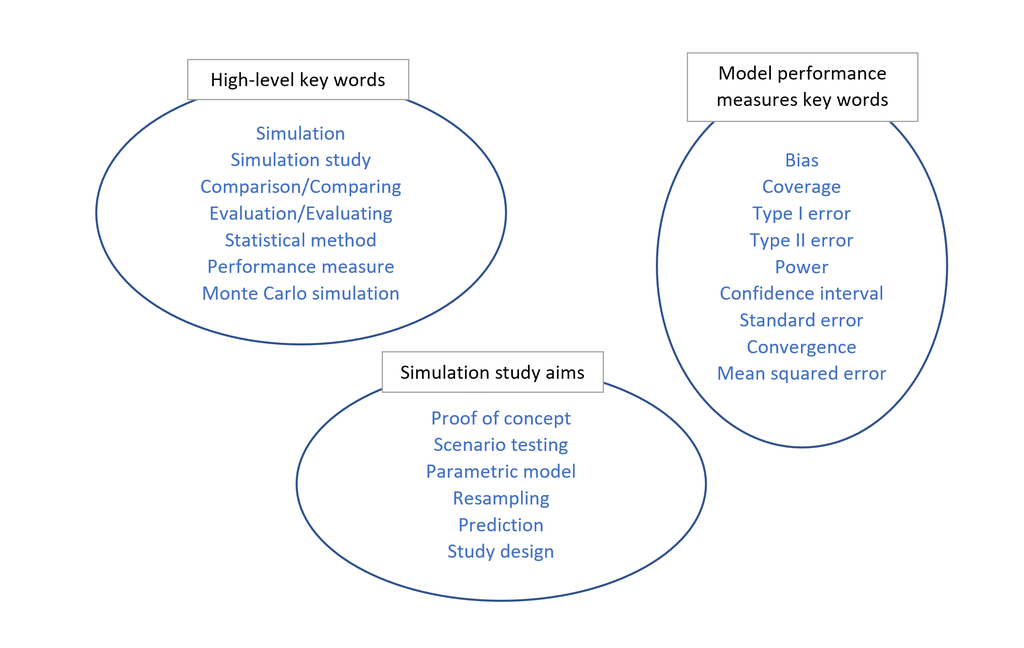

## Screening

### 1. Abstract and title screening

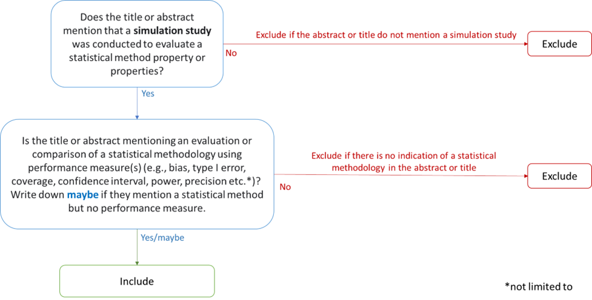

### 2. Full-text screening

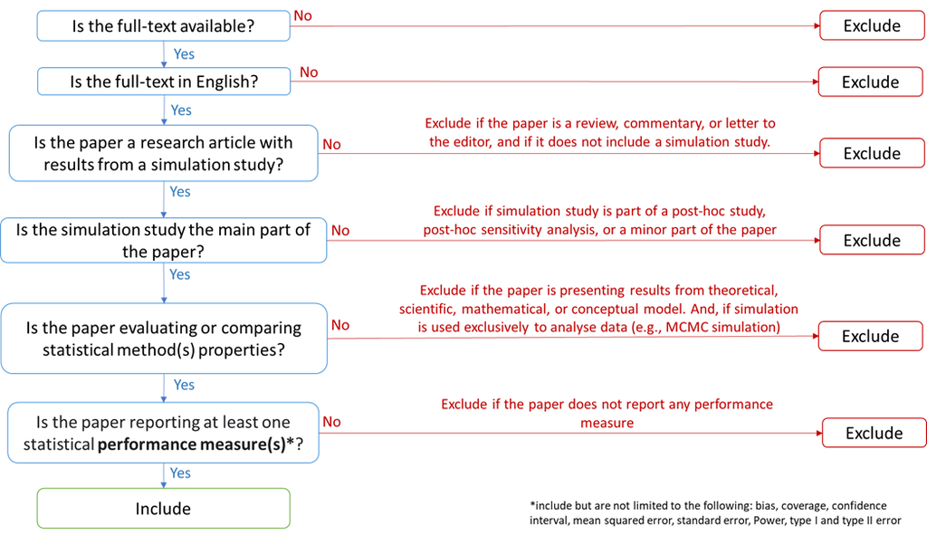

## Results

Screening results and PRISMA diagram

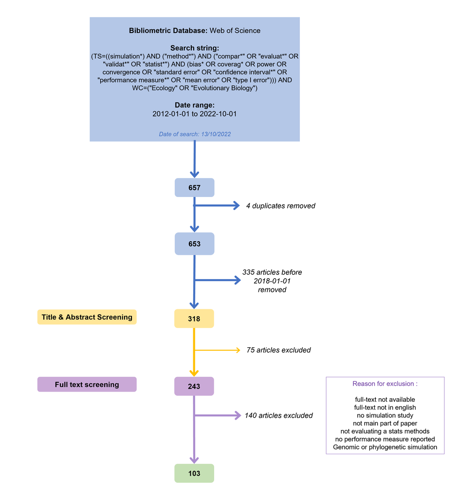

# 3. Text extraction

A total of 103 articles were included after full text screening for text extraction.

Full data extraction is currently being completed by one reviewer (CW). A second reviewer (YY) will cross-check at least 20% of the extracted data, and disagreements between the two reviewers will be discussed and resolved. Any unresolved conflicts will be mediated by a third reviewer (SN). Information will be extracted from each article using a pre-piloted custom Google Form available here: https://forms.gle/bWpDirw3owPJHcQq7

The paper-level information will be recorded: paper title, journal name, DOI, and publication year. Information extracted from each simulation study will record reporting and characteristics information from each simulation step (see Table 1, Table 2, and Table 3).

For each question, a comment field is provided for recording the justification for the answer and adding any additional comments that may be necessary.

## Table 1: Planning steps questions and options for text extraction

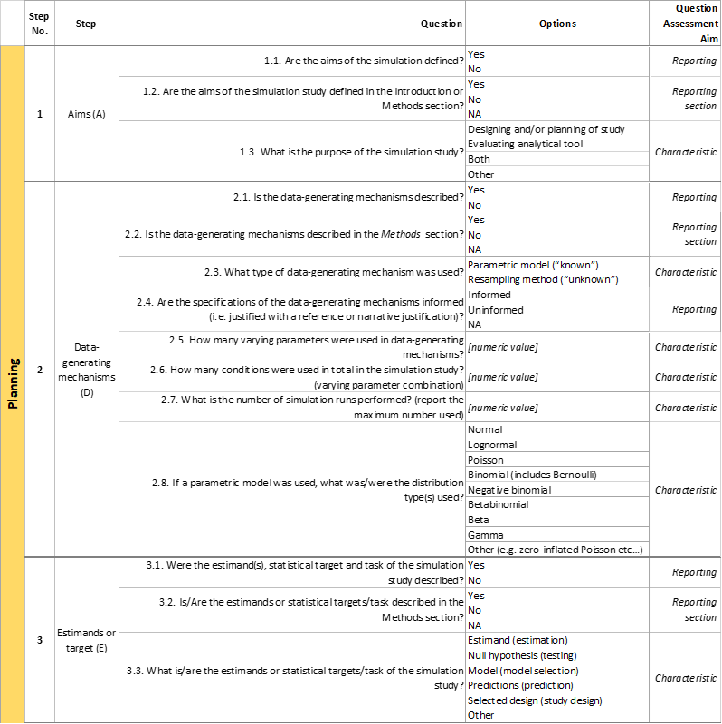

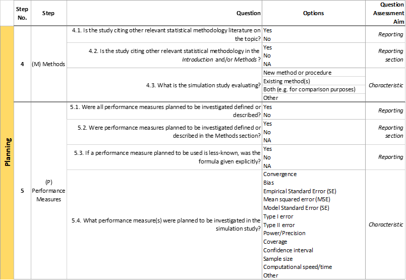

## Table 2: Coding steps questions and options for text extraction

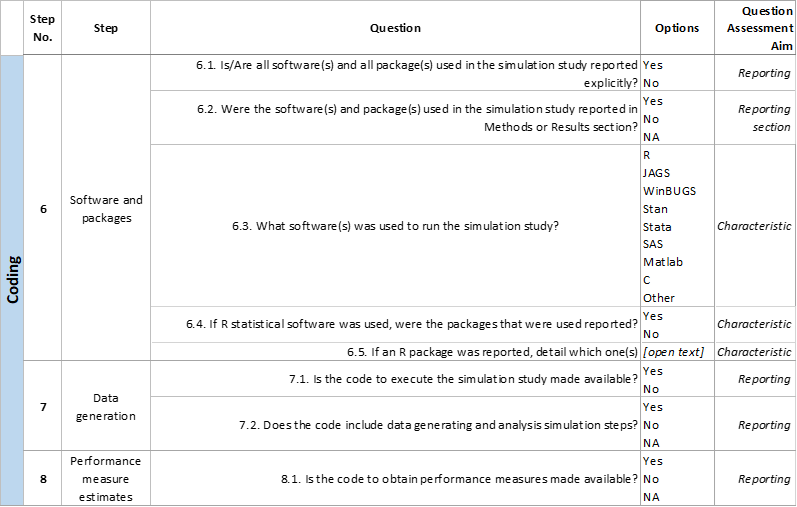

## Table 3: Analysis steps questions and options for text extraction

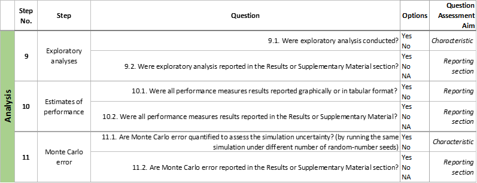

# 4. Data synthesis and analysis

This section describes future work (that is also described in the registered protocol document).

The information recorded in the Google form will be stored in a .csv Excel file for analysis and R statistical software will be used to produced graphs and data synthesis of extracted text.

#### a. Reporting practices results

The results from the reporting questions will be analysed by calculating the percentage of papers that answered “Yes,” indicating that the simulation studies correctly reported a simulation step. The results from the questions about the reporting section will also be summarised as a percentage of the number of “Yes” recorded, which indicates the simulation study included a key step in the expected paper section. These percentages will be displayed in both graphical and tabular formats.

#### b. Simulation study characteristic results

We will compare the different types of data-generating mechanisms, statistical task(s), performance measures, software, and packages reported in each simulation study. The results will be summarised in tabular format using counts for each item’s result and overall percentages. If the results reveal significant differences, we will conduct comparative analyses to explore the cause of these variations. Depending on the variability of the results, we may undertake additional analyses of the extracted data to understand the underlying reasons for any discrepancies.

#### c. Additional analyses

Depending on the results from the analyses of reporting and characteristic practices, additional analyses looking at differences between journals may be undertaken using comparative and descriptive statistics. We could expect to find differences between methodological journals vs non-methodological journals in ecology and evolutionary biology, with a higher reporting quality in the first group for example.

# Some important notes

**Genomic specific studies**

**Phylogenetic tree construction studies**

# Session info

[output not shown]

Main Session Information

| Component | Details |
| --- | --- |
| R | R version 4.2.2 (2022-10-31 ucrt) |
| Platform | x86_64-w64-mingw32/x64 (64-bit) |
| Language | R |

Loaded Packages

|  | Package | Version |
| --- | --- | --- |
| kableExtra | kableExtra | 1.3.4 |
| lubridate | lubridate | 1.9.2 |
| forcats | forcats | 1.0.0 |
| stringr | stringr | 1.5.0 |
| purrr | purrr | 1.0.1 |
| readr | readr | 2.1.4 |
| tidyr | tidyr | 1.3.0 |
| tibble | tibble | 3.2.1 |
| ggplot2 | ggplot2 | 3.4.2 |
| tidyverse | tidyverse | 2.0.0 |
| rlang | rlang | 1.1.1 |
| dplyr | dplyr | 1.1.2 |